# Plastic Pollution and its Economic Drivers

Author

Jonathan Flores Martinez, Avery Stewart, Justin Mai

# The Context of our Data

## Original Data Set

This was a data frame with information on plastic pollution. It was originally collected by the Break Free From Plastic (BFFP) group. They are an environmental activist with an interest in reducing the amount of plastic waste in the world. They focus on reducing the use of single use plastics and other actions across the entire life cycle of plastics. They believe that the best way to address plastic pollution comes from prevention over treating the effects of pollution. The data is two years (2019 and 2020) worth of data collected through global audits that BFFP does trying to understand the sources of plastic waste creation. The information provided by the data set is the country, parent company which created the plastic waste, the number of clean up events and volunteers, and the counts of plastic waste. This was unit-less so we are assuming individual plastic pieces collected at the event. There was a grand total count and multiple columns representing the different types of plastics ranging from the thin material of bags to PVC pipe plastic. Each row represents a country and company combination. There are over 10,000 rows of data.

This data was originally found in multiple folders one each for the years 2019 and 2020. Each folder then had a separate csv file for each country. jonthegeek used map_dfr to combine all the csv files into a single data frame. This function also changed the data types. All were turned into doubles as they were numbers except for the country and parent company as these were characters. He then added a year column as the ideas was to eventually combine the two years together. After cleaning up the names with janitor he did the same thing to the 2020 data. This one had some duplicate columns so he used an if_else function to take care of that. Finally the two years were bound together and some names were changed to make it easier to work with and we now have the data set we will be using.

## Country Statistics Data Set

The second dataset was obtained through a country statistics API and provide demographic and economic indicators for the countries represented in the plastics data. In this dataset, the observational unit is the country. Variables retrieved from the API include measures such as GDP, population, population density, employment by sector, and other indicators. The documentation for the API does not clearly identify the exact reference year for every variable, so this analysis uses variables that are relatively stable across the 2019–2020 period. The data is important since it provides demographic and economic context for understanding country differences in plastic collected during cleanup audits.

## Country Environmental Data Set

The third dataset was obtained through the Global Footprint Network API by pulling country level data for 2019 and 2020 from the National Footprint and Biocapacity Accounts. The API returns environmental and development indicators for countries and territories, including metrics such as Total Biocapacity and Total Ecological Footprint. After retrieving the data, I combined the yearly responses, reshaped them into a country year format, and matched them to the plastics dataset using country and year. This allowed me to incorporate environmental context into the original dataset and compare plastic collection outcomes with a nations ecological state.

# Research Questions

## Question 1

Which plastic types are the most abundant in the audits, does this change from country to country?

## Question 2

How do demographic and economic characteristics of countries along with their geographic characteristics associated with differences in plastic collected during cleanup audits?

# Data Summaries and Visualizations

```r
library(tidyverse)
library(gt)
library(httr)
library(stringr)
library(tidyjson)
library(jsonlite)
library(ggridges)
library(RColorBrewer)
library(viridis)
library(ggtext)
library(broom)
library(scales)
library(car)

plastics <- readr::read_csv('https://raw.githubusercontent.com/rfordatascience/tidytuesday/main/data/2021/2021-01-26/plastics.csv')

plastics_clean <- plastics |>
  mutate(across(empty:pvc, ~replace_na(., 0)),
         total = rowSums(across(c(empty:pvc))),
         .before = num_events)
final_merged <- readRDS("full_table")
#final_merged <- read_csv("/Users/avery/Desktop/stat541/project-1/final_table.csv")
```

## Data Summaries

### Proportions of Plastics for the 5 Most Populated Countries

```r
proportions <- function(df) {

  df |>
    select(country:pvc) |>
    map_if(is.numeric, ~.x / df$grand_total) |>
    as.data.frame()
}

plastics_clean |>
    mutate(year = factor(year)) |>
    group_by(country, year) |>
    summarize(across(empty:total,
                     ~sum(.x, na.rm = TRUE)),
              .groups = "drop") |>
  proportions() |>
  filter(country %in% c("India",
                        "China",
                        "United States of America",
                        "Indonesia",
                        "Nigeria")) |>
  gt() |>
  fmt_percent(columns = empty:pvc) |>
  tab_style(style = cell_text(weight = "bold"),
    locations = cells_column_labels()) |>
  tab_caption("Percentage of Each Plastic Type Found in Audits From
              the 5 Most Populated Countries by Year") |>
  cols_move_to_end(o) |>
  cols_label(country = "Country",
             year = "Year",
             empty = "Empty",
             hdpe = "HDPE",
             ldpe = "LDPE",
             o = "Other",
             pet = "PET",
             pp = "PP",
             ps = "PS",
             pvc = "PVC")  |>
  data_color(
    method = "numeric",
    palette = "plasma",
    reverse = FALSE
  )
```

Table 1: Proportions of Each Plastic Type for the 5 Most Populated Countries

Percentage of Each Plastic Type Found in Audits From the 5 Most Populated Countries by Year

| Country | Year | Empty | HDPE | LDPE | PET | PP | PS | PVC | Other |
| --- | --- | --- | --- | --- | --- | --- | --- | --- | --- |
| China | 2019 | 0.00% | 0.00% | 0.00% | 34.20% | 0.00% | 0.00% | 0.00% | 65.80% |
| China | 2020 | 0.00% | 0.09% | 0.00% | 5.40% | 0.00% | 0.00% | 0.00% | 94.51% |
| India | 2019 | 0.00% | 0.10% | 31.99% | 11.57% | 3.78% | 4.70% | 0.19% | 47.68% |
| India | 2020 | 0.13% | 2.88% | 39.38% | 5.27% | 6.52% | 0.39% | 2.00% | 43.42% |
| Indonesia | 2019 | 0.00% | 1.47% | 21.02% | 26.73% | 8.93% | 10.26% | 0.18% | 31.41% |
| Indonesia | 2020 | 0.07% | 12.84% | 14.39% | 27.75% | 28.67% | 1.43% | 0.35% | 14.50% |
| Nigeria | 2020 | 0.50% | 11.91% | 24.46% | 43.30% | 3.53% | 3.18% | 0.03% | 13.10% |
| United States of America | 2019 | 0.00% | 0.46% | 3.92% | 3.92% | 67.52% | 1.58% | 0.00% | 22.60% |
| United States of America | 2020 | 3.39% | 4.67% | 5.90% | 22.17% | 25.10% | 5.41% | 1.28% | 32.05% |

```r
country_profile <- function(data, group_var1, group_var2, min_audits = 10) {
  data |>
    filter(!is.na(country), country != "EMPTY",
           country %in% c("India",
                        "China",
                        "United States of America",
                        "Indonesia",
                        "Nigeria")) |>
    group_by({{ group_var1 }}, {{ group_var2 }}) |>
    summarise(
      audits = n(),
      total_pieces = sum(grand_total),
      median_pieces = median(grand_total),
      mean_pieces = mean(grand_total),
      max_pieces = max(grand_total),
      .groups = "drop"
    ) |>
    filter(audits >= min_audits) |>
    arrange({{ group_var1 }}, {{ group_var2 }}) |>
    mutate(country = str_to_title(country)) |>
    gt() |>
    tab_header(
      title = md(
        paste0(
          "**Table.** Plastic cleanup profile by country and year for countries
          with at least ",
           min_audits,
          " audits."
        )
      )
  ) |>
  fmt_number(
    columns = c(audits, total_pieces, median_pieces, mean_pieces, max_pieces),
    decimals = 1,
    use_seps = TRUE
  ) |>
  cols_label(
    country = md("**Country**"),
    year = md("**Year**"),
    audits = md("**Audits**"),
    total_pieces = md("**Total Pieces**"),
    median_pieces = md("**Median Pieces**"),
    mean_pieces = md("**Mean Pieces**"),
    max_pieces = md("**Max Pieces**")
  )
}


country_profile(plastics_clean, country, year, min_audits = 1)
```

Table 2: Summary Statistics of Audits by Country and Year for the 5 Most Populated Countries

**Table.** Plastic cleanup profile by country and year for countries with at least 1 audits.

| **Country** | **Year** | **Audits** | **Total Pieces** | **Median Pieces** | **Mean Pieces** | **Max Pieces** |
| --- | --- | --- | --- | --- | --- | --- |
| China | 2019 | 622.0 | 6,918.0 | 1.0 | 11.1 | 3,459.0 |
| China | 2020 | 216.0 | 2,332.0 | 1.0 | 10.8 | 207.0 |
| India | 2019 | 209.0 | 4,132.0 | 1.0 | 19.8 | 2,066.0 |
| India | 2020 | 348.0 | 16,973.0 | 3.0 | 48.8 | 4,250.0 |
| Indonesia | 2019 | 636.0 | 26,618.0 | 1.0 | 41.9 | 13,309.0 |
| Indonesia | 2020 | 294.0 | 10,156.0 | 2.0 | 34.5 | 3,710.0 |
| Nigeria | 2020 | 335.0 | 63,253.0 | 4.0 | 188.8 | 30,200.0 |
| United States Of America | 2019 | 583.0 | 8,628.0 | 0.0 | 14.8 | 4,314.0 |
| United States Of America | 2020 | 376.0 | NA | NA | NA | NA |

## Visualizations

### Ridge Plot Showing Plastic Waste Type Distribution by Country GDP per Capita

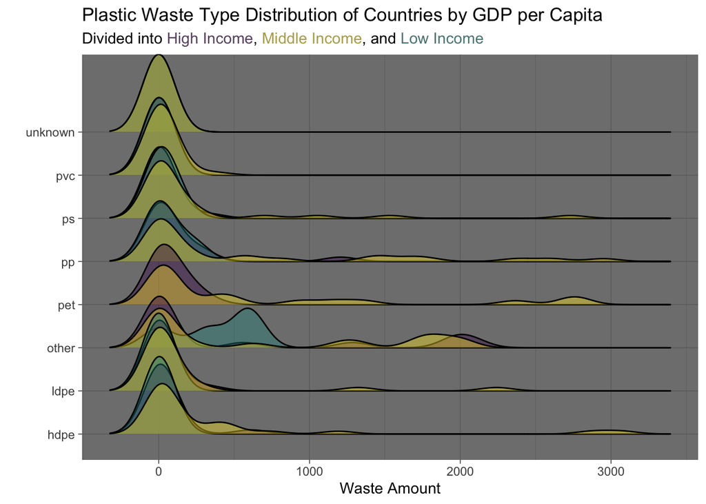

Figure 1: Ridge Plot Showing the Amount of Plastic Waste for Each Type of Plastic

```r
final_merged |>
  filter(year == 2019) |>
  group_by(country) |>
  summarize(unknown = sum(empty),
            hdpe = sum(hdpe),
            ldpe = sum(ldpe),
            other = sum(o),
            pet = sum(pet),
            pp = sum(pp),
            ps = sum(ps),
            pvc = sum(pvc),
            total = sum(total),
            gdp_per_capita = mean(gdp_per_capita),
            hdi = mean(HDI),
            .groups = "drop") |>
  mutate(income_group = case_when(
    gdp_per_capita < 1500 ~ "Low Income",
    gdp_per_capita > 12000 ~ "High Income",
    TRUE ~ "Middle Income")) |>
  pivot_longer(
    cols = unknown:pvc,
    names_to = "plastic_type",
    values_to = "waste") |>
  filter(waste <= 3500) |>

  ggplot(mapping = aes(x = waste,
                       y = plastic_type,
                       fill = income_group)) +
  geom_density_ridges(alpha = 0.4) +
  scale_fill_viridis(discrete=TRUE) +
  labs(
    title = "Plastic Waste Type Distribution of Countries by GDP per Capita",
    subtitle = "Divided into <span style='color: #6a546f;'>High Income</span>,
      <span style='color: #b5aa5f;'>Middle Income</span>,
    and <span style='color: #5e8684;'>Low Income</span>",
    x = "Waste Amount",
    y = "",
    alt = "Density ridge plot showing the density of plastic waste audited
    for multiple types of plastic. Colored by GDP per capita category,
    High, Middle, and Low") +
  theme_dark() +
  theme(plot.subtitle =  element_markdown(),
        legend.position = "none")
```

### Bubble Plot

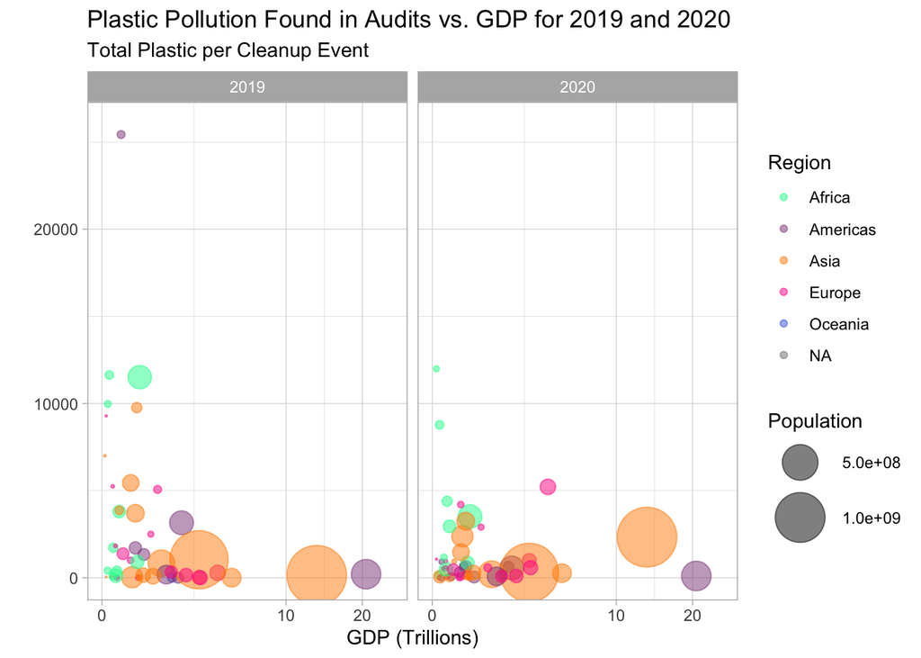

Figure 2: Bubble Plot of Plastic Pollution From Audits Against GDP for 2019 and 2020

```r
final_merged |>
  mutate(region = countrycode::countrycode(country,
            origin = "country.name",
            destination = "continent"),
         total_normalized = total / num_events,
         gdp_trillions = gdp / 1e6) |>
  filter_out(country == "EMPTY",
           total == 0,
           is.na(total),
           is.na(gdp_trillions),
           gdp_trillions == 0,
           is.na(region)) |>
  group_by(country, region, year) |>
  summarize(total_plastic = sum(total_normalized, na.rm = T),
            gdp_trillions = mean(gdp_trillions, na.rm = T),
            Population = mean(Population, na.rm = T)) |>
  ggplot(aes(x = gdp_trillions, y = total_plastic, size = Population,
             color = region)) +
    geom_point(alpha = 0.5) +
    scale_size(range = c(.1, 15), name ="Population") +
  labs(color = "Region",
       x = "GDP (Trillions)",
       title = "Plastic Pollution Found in Audits vs. GDP for 2019 and 2020",
       subtitle = "Total Plastic per Cleanup Event",
       y = "",
       alt = "Bubble chart showing plastic items found per cleanup event vs GDP in trillions,
       colored by region and sized by population") +
  coord_cartesian(ylim = c(0, 26000),
                  xlim = c(0,25)) +
  scale_color_discrete(na.translate = FALSE) +
  scale_x_sqrt() +
  facet_wrap(~ year) +
  theme_light() + scale_color_manual(values = c("Africa" = "mediumspringgreen", "Americas" = "orchid4",
                                "Asia" = "darkorange", "Europe" = "deeppink",
                                "Oceania" = "royalblue"))
```

# Data Model

```r
model_df <- final_merged |>
  group_by(country, year) |>
  summarise(
    total_plastic = sum(total, na.rm = TRUE),
    Population_millions = first(na.omit(Population)) / 1000000,
    pop_density = first(na.omit(pop_density)),
    gdp_billions = first(na.omit(gdp)) / 1000000000,
    region = first(na.omit(region)),
    .groups = "drop"
  ) |>
  mutate(
    region = as.factor(region),
    log_total_plastic = log(total_plastic)
  )

fit_6 <- lm(
  log_total_plastic ~ Population_millions + pop_density + gdp_billions + region,
  model_df
)

tbl <- tidy(fit_6, conf.int = TRUE) |>
  mutate(
    Predictor = dplyr::recode(term,
      `(Intercept)` = "Intercept",
      `Population_millions` = "Population (millions)",
      `pop_density` = "Population Density",
      `gdp_billions` = "GDP (billions)"
    ),
    Predictor = sub("^region", "Region: ", Predictor)
  ) |>
  select(
    Predictor,
    Estimate = estimate,
    `Std. Error` = std.error,
    `t value` = statistic,
    `p value` = p.value,
    `95% CI Lower` = conf.low,
    `95% CI Upper` = conf.high
  )

tbl |>
  gt() |>
  tab_header(
    title = md("**Linear Regression Predicting Logged Plastic Collected by Country, Year**"),
    subtitle = "Response: log(total_plastic)"
  ) |>
  cols_label(
    Predictor = md("**Predictor**"),
    Estimate = md("**Estimate**"),
    `Std. Error` = md("**Std. Error**"),
    `t value` = md("**t value**"),
    `p value` = md("**p value**"),
    `95% CI Lower` = md("**95% CI Lower**"),
    `95% CI Upper` = md("**95% CI Upper**")
  ) |>
  fmt_number(
    columns = c(Estimate, `Std. Error`, `t value`, `95% CI Lower`, `95% CI Upper`),
    decimals = 4
  ) |>
  fmt_number(columns = `p value`, decimals = 3) |>
  tab_source_note(
    source_note = md(
       "The response variable was transformed as log(total_plastic) to meet linear regression assumptions"
    )
  )
```

**Linear Regression Predicting Logged Plastic Collected by Country, Year**

Response: log(total_plastic)

| **Predictor** | **Estimate** | **Std. Error** | **t value** | **p value** | **95% CI Lower** | **95% CI Upper** |
| --- | --- | --- | --- | --- | --- | --- |
| Intercept | 5.4932 | 1.1349 | 4.8402 | 0.000 | 3.2359 | 7.7505 |
| Population (millions) | 0.0015 | 0.0012 | 1.2577 | 0.212 | −0.0009 | 0.0039 |
| Population Density | −0.0006 | 0.0003 | −2.0672 | 0.042 | −0.0012 | 0.0000 |
| GDP (billions) | 160.7701 | 115.7806 | 1.3886 | 0.169 | −69.5128 | 391.0530 |
| Region: Eastern Africa | 3.0035 | 1.5196 | 1.9766 | 0.051 | −0.0188 | 6.0259 |
| Region: Eastern Asia | −0.5729 | 1.6740 | −0.3422 | 0.733 | −3.9024 | 2.7566 |
| Region: Eastern Europe | 0.8096 | 1.5195 | 0.5328 | 0.596 | −2.2126 | 3.8319 |
| Region: Middle Africa | 4.2469 | 2.5316 | 1.6776 | 0.097 | −0.7883 | 9.2821 |
| Region: Northern Africa | 0.5925 | 1.9615 | 0.3020 | 0.763 | −3.3088 | 4.4937 |
| Region: Northern America | −0.8434 | 1.9687 | −0.4284 | 0.669 | −4.7591 | 3.0722 |
| Region: Northern Europe | 0.2497 | 1.3883 | 0.1799 | 0.858 | −2.5116 | 3.0110 |
| Region: Oceania | −1.1579 | 1.9652 | −0.5892 | 0.557 | −5.0666 | 2.7508 |
| Region: South America | 2.1694 | 1.3395 | 1.6196 | 0.109 | −0.4948 | 4.8335 |
| Region: South-Eastern Asia | 3.7058 | 1.3444 | 2.7564 | 0.007 | 1.0318 | 6.3798 |
| Region: Southern Africa | 1.5155 | 1.9607 | 0.7730 | 0.442 | −2.3842 | 5.4152 |
| Region: Southern Asia | 0.9942 | 1.4534 | 0.6840 | 0.496 | −1.8965 | 3.8848 |
| Region: Southern Europe | 1.4958 | 1.3082 | 1.1434 | 0.256 | −1.1061 | 4.0978 |
| Region: Western Africa | 3.5947 | 1.3614 | 2.6404 | 0.010 | 0.8869 | 6.3025 |
| Region: Western Asia | −1.8473 | 1.4620 | −1.2635 | 0.210 | −4.7551 | 1.0605 |
| Region: Western Europe | 1.3120 | 1.3705 | 0.9573 | 0.341 | −1.4139 | 4.0378 |

The response variable was transformed as log(total_plastic) to meet linear regression assumptions

## Conclusion

This report examined two questions about plastic pollution using cleanup audit data and additional country datasets. First, the analysis showed that plastic composition varies across countries, although several categories such as PET, PP, and LDPE appear repeatedly among the most common forms of collected waste. Second, the analysis found that differences in plastic collected across countries are more closely associated with regional context and population density than with GDP alone. Taken together, these results suggest that plastic pollution is shaped by both the composition of consumer waste and the demographic and geographic setting in which that waste is collected.